# Real-world Data Wrangling

In this project, you will apply the skills you acquired in the course to gather and wrangle real-world data with two datasets of your choice.

You will retrieve and extract the data, assess the data programmatically and visually, accross elements of data quality and structure, and implement a cleaning strategy for the data. You will then store the updated data into your selected database/data store, combine the data, and answer a research question with the datasets.

Throughout the process, you are expected to:

1. Explain your decisions towards methods used for gathering, assessing, cleaning, storing, and answering the research question
2. Write code comments so your code is more readable

Before you start, install the some of the required packages.

```python
!python -m pip install kaggle==1.6.12
```

```python
!pip install --target=/workspace ucimlrepo
```

[output not shown]

**Note:** Restart the kernel to use updated package(s).

## 1. Gather data

In this section, you will extract data using two different data gathering methods and combine the data. Use at least two different types of data-gathering methods.

### **1.1.** Problem Statement

For this project, I want to determine if there is a statistically significant difference in the average cases and deaths per day of covid-19 patients during the summer of 2020 between New York City and Chicago. I will be using two different datasets that display the daily cases, deaths, and hospitalizations of Covid-19 patients between the two respective cities.

Finding the right datasets can be time-consuming. Here we provide you with a list of websites to start with. But we encourage you to explore more websites and find the data that interests you.

- Google Dataset Search https://datasetsearch.research.google.com/
- The U.S. Government’s open data https://data.gov/
- UCI Machine Learning Repository https://archive.ics.uci.edu/ml/index.php

### **1.2.** Gather at least two datasets using two different data gathering methods

List of data gathering methods:

- Download data manually
- Programmatically downloading files
- Gather data by accessing APIs
- Gather and extract data from HTML files using BeautifulSoup
- Extract data from a SQL database

Each dataset must have at least two variables, and have greater than 500 data samples within each dataset.

For each dataset, briefly describe why you picked the dataset and the gathering method (2-3 full sentences), including the names and significance of the variables in the dataset. Show your work (e.g., if using an API to download the data, please include a snippet of your code).

Load the dataset programmtically into this notebook.

#### **Dataset 1**

```python
#FILL IN 1st data gathering and loading method
import pandas as pd

#read the new york csv file
nyc_df = pd.read_csv('COVID-19_Daily_Counts_of_Cases__Hospitalizations__and_Deaths_20240608.csv')
```

#### Dataset 2

```python
#FILL IN 2nd data gathering and loading method
import pandas as pd

#read chicago csv file
chi_df = pd.read_csv('COVID-19_Daily_Cases__Deaths__and_Hospitalizations_-_Historical_20240608.csv')
```

Optional data storing step: You may save your raw dataset files to the local data store before moving to the next step.

```python
#Optional: store the raw data in your local data store
```

## 2. Assess data

Assess the data according to data quality and tidiness metrics using the report below.

List **two** data quality issues and **two** tidiness issues. Assess each data issue visually **and** programmatically, then briefly describe the issue you find. **Make sure you include justifications for the methods you use for the assessment.**

### Quality Issue 1:

```python
#FILL IN - Inspecting the dataframe visually
nyc_df.head(10)
```

|  | date_of_interest | CASE_COUNT | PROBABLE_CASE_COUNT | HOSPITALIZED_COUNT | DEATH_COUNT | CASE_COUNT_7DAY_AVG | ALL_CASE_COUNT_7DAY_AVG | HOSP_COUNT_7DAY_AVG | DEATH_COUNT_7DAY_AVG | BX_CASE_COUNT | ... | SI_CASE_COUNT | SI_PROBABLE_CASE_COUNT | SI_HOSPITALIZED_COUNT | SI_DEATH_COUNT | SI_PROBABLE_CASE_COUNT_7DAY_AVG | SI_CASE_COUNT_7DAY_AVG | SI_ALL_CASE_COUNT_7DAY_AVG | SI_HOSPITALIZED_COUNT_7DAY_AVG | SI_DEATH_COUNT_7DAY_AVG | INCOMPLETE |
| --- | --- | --- | --- | --- | --- | --- | --- | --- | --- | --- | --- | --- | --- | --- | --- | --- | --- | --- | --- | --- | --- |
| 0 | 02/29/2020 | 1 | 0 | 1 | 0 | 0 | 0 | 0 | 0 | 0 | ... | 0 | 0 | 0 | 0 | 0 | 0 | 0 | 0 | 0 | 0 |
| 1 | 03/01/2020 | 0 | 0 | 1 | 0 | 0 | 0 | 0 | 0 | 0 | ... | 0 | 0 | 0 | 0 | 0 | 0 | 0 | 0 | 0 | 0 |
| 2 | 03/02/2020 | 0 | 0 | 2 | 0 | 0 | 0 | 0 | 0 | 0 | ... | 0 | 0 | 0 | 0 | 0 | 0 | 0 | 0 | 0 | 0 |
| 3 | 03/03/2020 | 1 | 0 | 7 | 0 | 0 | 0 | 0 | 0 | 0 | ... | 0 | 0 | 0 | 0 | 0 | 0 | 0 | 0 | 0 | 0 |
| 4 | 03/04/2020 | 5 | 0 | 2 | 0 | 0 | 0 | 0 | 0 | 0 | ... | 0 | 0 | 0 | 0 | 0 | 0 | 0 | 0 | 0 | 0 |
| 5 | 03/05/2020 | 3 | 0 | 14 | 0 | 0 | 0 | 0 | 0 | 0 | ... | 0 | 0 | 1 | 0 | 0 | 0 | 0 | 0 | 0 | 0 |
| 6 | 03/06/2020 | 8 | 0 | 8 | 0 | 3 | 3 | 5 | 0 | 2 | ... | 1 | 0 | 1 | 0 | 0 | 0 | 0 | 0 | 0 | 0 |
| 7 | 03/07/2020 | 7 | 0 | 8 | 0 | 3 | 3 | 6 | 0 | 0 | ... | 1 | 0 | 0 | 0 | 0 | 0 | 0 | 0 | 0 | 0 |
| 8 | 03/08/2020 | 21 | 0 | 18 | 0 | 6 | 6 | 8 | 0 | 3 | ... | 1 | 0 | 0 | 0 | 0 | 0 | 0 | 0 | 0 | 0 |
| 9 | 03/09/2020 | 57 | 0 | 37 | 0 | 15 | 15 | 13 | 0 | 4 | ... | 3 | 0 | 2 | 0 | 0 | 1 | 1 | 1 | 0 | 0 |

10 rows × 55 columns

```python
#FILL IN - Inspecting the dataframe programmatically
nyc_df.describe()
```

|  | CASE_COUNT | PROBABLE_CASE_COUNT | HOSPITALIZED_COUNT | DEATH_COUNT | CASE_COUNT_7DAY_AVG | ALL_CASE_COUNT_7DAY_AVG | HOSP_COUNT_7DAY_AVG | DEATH_COUNT_7DAY_AVG | BX_CASE_COUNT | BX_PROBABLE_CASE_COUNT | ... | SI_CASE_COUNT | SI_PROBABLE_CASE_COUNT | SI_HOSPITALIZED_COUNT | SI_DEATH_COUNT | SI_PROBABLE_CASE_COUNT_7DAY_AVG | SI_CASE_COUNT_7DAY_AVG | SI_ALL_CASE_COUNT_7DAY_AVG | SI_HOSPITALIZED_COUNT_7DAY_AVG | SI_DEATH_COUNT_7DAY_AVG | INCOMPLETE |
| --- | --- | --- | --- | --- | --- | --- | --- | --- | --- | --- | --- | --- | --- | --- | --- | --- | --- | --- | --- | --- | --- |
| count | 1557.000000 | 1557.000000 | 1557.000000 | 1557.000000 | 1557.000000 | 1557.000000 | 1557.000000 | 1557.000000 | 1557.000000 | 1557.000000 | ... | 1557.000000 | 1557.000000 | 1557.000000 | 1557.000000 | 1557.000000 | 1557.000000 | 1557.000000 | 1557.000000 | 1557.000000 | 1557.000000 |
| mean | 1877.055234 | 412.734746 | 136.680796 | 29.794477 | 1876.524085 | 2289.026333 | 136.644830 | 29.785485 | 311.466924 | 81.593449 | ... | 131.537572 | 29.764290 | 8.274245 | 1.817598 | 29.747592 | 131.517662 | 161.261400 | 8.272319 | 1.785485 | 274.380218 |
| std | 4305.097141 | 549.930518 | 216.383411 | 85.269949 | 3969.764092 | 4445.813840 | 212.785539 | 84.261537 | 798.899754 | 125.096060 | ... | 283.248448 | 32.963391 | 10.498314 | 3.991813 | 30.696644 | 261.355406 | 286.227498 | 10.038824 | 3.788797 | 4084.220082 |
| min | 0.000000 | 0.000000 | 0.000000 | 0.000000 | 0.000000 | 0.000000 | 0.000000 | 0.000000 | 0.000000 | 0.000000 | ... | 0.000000 | 0.000000 | 0.000000 | 0.000000 | 0.000000 | 0.000000 | 0.000000 | 0.000000 | 0.000000 | 0.000000 |
| 25% | 343.000000 | 94.000000 | 35.000000 | 4.000000 | 345.000000 | 448.000000 | 35.000000 | 4.000000 | 55.000000 | 15.000000 | ... | 23.000000 | 7.000000 | 2.000000 | 0.000000 | 7.000000 | 24.000000 | 31.000000 | 2.000000 | 0.000000 | 0.000000 |
| 50% | 906.000000 | 283.000000 | 72.000000 | 9.000000 | 940.000000 | 1279.000000 | 72.000000 | 9.000000 | 134.000000 | 51.000000 | ... | 64.000000 | 21.000000 | 5.000000 | 1.000000 | 23.000000 | 70.000000 | 96.000000 | 5.000000 | 1.000000 | 0.000000 |
| 75% | 2049.000000 | 550.000000 | 141.000000 | 19.000000 | 2153.000000 | 2690.000000 | 140.000000 | 18.000000 | 315.000000 | 110.000000 | ... | 151.000000 | 44.000000 | 11.000000 | 2.000000 | 44.000000 | 153.000000 | 196.000000 | 10.000000 | 2.000000 | 0.000000 |
| max | 55057.000000 | 5882.000000 | 1858.000000 | 831.000000 | 39531.000000 | 43988.000000 | 1687.000000 | 775.000000 | 10564.000000 | 1575.000000 | ... | 3720.000000 | 316.000000 | 83.000000 | 43.000000 | 233.000000 | 2689.000000 | 2909.000000 | 72.000000 | 34.000000 | 61030.000000 |

8 rows × 54 columns

Issue and justification: There are many columns that are not relevant to my research question. I plan to not include these columns in my altered dataset.

### Quality Issue 2:

```python
#FILL IN - Inspecting the dataframe visually
chi_df.head(10)
```

|  | Date | Cases - Total | Deaths - Total | Hospitalizations - Total | Cases - Age 0-17 | Cases - Age 18-29 | Cases - Age 30-39 | Cases - Age 40-49 | Cases - Age 50-59 | Cases - Age 60-69 | ... | Hospitalizations - Age Unknown | Hospitalizations - Female | Hospitalizations - Male | Hospitalizations - Unknown Gender | Hospitalizations - Latinx | Hospitalizations - Asian Non-Latinx | Hospitalizations - Black Non-Latinx | Hospitalizations - White Non-Latinx | Hospitalizations - Other Race Non-Latinx | Hospitalizations - Unknown Race/Ethnicity |
| --- | --- | --- | --- | --- | --- | --- | --- | --- | --- | --- | --- | --- | --- | --- | --- | --- | --- | --- | --- | --- | --- |
| 0 | 03/06/2020 | 3 | 0 | 2.0 | 0 | 0 | 0 | 2 | 0 | 1 | ... | 0.0 | 1.0 | 1.0 | 0.0 | 0.0 | 0.0 | 1.0 | 1.0 | 0.0 | 0.0 |
| 1 | 03/07/2020 | 3 | 0 | 3.0 | 0 | 0 | 0 | 0 | 1 | 0 | ... | 0.0 | 1.0 | 2.0 | 0.0 | 0.0 | 0.0 | 1.0 | 1.0 | 1.0 | 0.0 |
| 2 | 03/14/2020 | 31 | 0 | 9.0 | 0 | 9 | 2 | 7 | 6 | 3 | ... | 0.0 | 7.0 | 2.0 | 0.0 | 2.0 | 0.0 | 4.0 | 3.0 | 0.0 | 0.0 |
| 3 | 03/12/2020 | 21 | 0 | 7.0 | 0 | 6 | 5 | 2 | 4 | 3 | ... | 0.0 | 3.0 | 4.0 | 0.0 | 0.0 | 1.0 | 4.0 | 2.0 | 0.0 | 0.0 |
| 4 | 03/03/2020 | 0 | 0 | 3.0 | 0 | 0 | 0 | 0 | 0 | 0 | ... | 0.0 | 1.0 | 2.0 | 0.0 | 0.0 | 0.0 | 3.0 | 0.0 | 0.0 | 0.0 |
| 5 | 03/09/2020 | 5 | 0 | 3.0 | 3 | 0 | 0 | 0 | 0 | 0 | ... | 0.0 | 1.0 | 2.0 | 0.0 | 1.0 | 0.0 | 0.0 | 2.0 | 0.0 | 0.0 |
| 6 | 03/01/2020 | 0 | 0 | 2.0 | 0 | 0 | 0 | 0 | 0 | 0 | ... | 0.0 | 1.0 | 1.0 | 0.0 | 0.0 | 0.0 | 0.0 | 2.0 | 0.0 | 0.0 |
| 7 | 03/08/2020 | 3 | 0 | 7.0 | 0 | 0 | 1 | 1 | 0 | 0 | ... | 0.0 | 3.0 | 4.0 | 0.0 | 2.0 | 0.0 | 4.0 | 1.0 | 0.0 | 0.0 |
| 8 | 03/02/2020 | 0 | 0 | 1.0 | 0 | 0 | 0 | 0 | 0 | 0 | ... | 0.0 | 1.0 | 0.0 | 0.0 | 1.0 | 0.0 | 0.0 | 0.0 | 0.0 | 0.0 |
| 9 | 03/11/2020 | 13 | 0 | 7.0 | 0 | 4 | 1 | 3 | 3 | 2 | ... | 0.0 | 4.0 | 3.0 | 0.0 | 1.0 | 0.0 | 5.0 | 1.0 | 0.0 | 0.0 |

10 rows × 58 columns

```python
#FILL IN - Inspecting the dataframe programmatically
chi_df.describe()
```

|  | Cases - Total | Deaths - Total | Hospitalizations - Total | Cases - Age 0-17 | Cases - Age 18-29 | Cases - Age 30-39 | Cases - Age 40-49 | Cases - Age 50-59 | Cases - Age 60-69 | Cases - Age 70-79 | ... | Hospitalizations - Age Unknown | Hospitalizations - Female | Hospitalizations - Male | Hospitalizations - Unknown Gender | Hospitalizations - Latinx | Hospitalizations - Asian Non-Latinx | Hospitalizations - Black Non-Latinx | Hospitalizations - White Non-Latinx | Hospitalizations - Other Race Non-Latinx | Hospitalizations - Unknown Race/Ethnicity |
| --- | --- | --- | --- | --- | --- | --- | --- | --- | --- | --- | --- | --- | --- | --- | --- | --- | --- | --- | --- | --- | --- |
| count | 1540.000000 | 1540.000000 | 1538.000000 | 1540.000000 | 1540.000000 | 1540.000000 | 1540.000000 | 1540.000000 | 1540.000000 | 1540.000000 | ... | 1538.000000 | 1538.000000 | 1538.000000 | 1538.000000 | 1538.000000 | 1538.000000 | 1538.000000 | 1538.000000 | 1538.000000 | 1538.000000 |
| mean | 534.794156 | 5.437013 | 37.858257 | 87.674675 | 116.009740 | 102.918182 | 76.046104 | 64.214935 | 46.165584 | 25.470130 | ... | 0.011053 | 19.028609 | 18.823797 | 0.005852 | 9.249025 | 1.138492 | 16.892718 | 8.072822 | 1.628088 | 0.877113 |
| std | 886.654160 | 8.959982 | 44.185428 | 179.268353 | 213.472571 | 179.944883 | 125.832050 | 99.977541 | 65.678677 | 31.303391 | ... | 0.104586 | 21.653039 | 23.063873 | 0.076297 | 12.876967 | 2.054796 | 20.367561 | 8.632520 | 2.531939 | 1.357352 |
| min | 0.000000 | 0.000000 | 1.000000 | 0.000000 | 0.000000 | 0.000000 | 0.000000 | 0.000000 | 0.000000 | 0.000000 | ... | 0.000000 | 0.000000 | 0.000000 | 0.000000 | 0.000000 | 0.000000 | 0.000000 | 0.000000 | 0.000000 | 0.000000 |
| 25% | 148.000000 | 0.000000 | 15.000000 | 18.000000 | 24.000000 | 24.000000 | 19.000000 | 18.000000 | 15.000000 | 9.000000 | ... | 0.000000 | 7.250000 | 7.000000 | 0.000000 | 3.000000 | 0.000000 | 6.000000 | 3.000000 | 0.000000 | 0.000000 |
| 50% | 328.000000 | 2.000000 | 26.000000 | 45.000000 | 61.000000 | 59.000000 | 43.000000 | 37.000000 | 28.000000 | 16.000000 | ... | 0.000000 | 13.000000 | 12.000000 | 0.000000 | 5.000000 | 1.000000 | 11.000000 | 6.000000 | 1.000000 | 0.000000 |
| 75% | 571.250000 | 6.000000 | 42.000000 | 94.000000 | 123.250000 | 114.000000 | 81.250000 | 69.250000 | 54.000000 | 32.000000 | ... | 0.000000 | 22.000000 | 20.750000 | 0.000000 | 10.000000 | 2.000000 | 20.000000 | 10.000000 | 2.000000 | 1.000000 |
| max | 10423.000000 | 58.000000 | 811.000000 | 2816.000000 | 2295.000000 | 2008.000000 | 1394.000000 | 1115.000000 | 741.000000 | 333.000000 | ... | 1.000000 | 391.000000 | 420.000000 | 1.000000 | 241.000000 | 56.000000 | 281.000000 | 172.000000 | 40.000000 | 21.000000 |

8 rows × 57 columns

Issue and justification: There are many columns that represent variables not relevant to the research question. I plan to not include these columns in my altered dataset.

### Tidiness Issue 1:

```python
#FILL IN - Inspecting the dataframe visually
nyc_df.head(10)
```

|  | date_of_interest | CASE_COUNT | PROBABLE_CASE_COUNT | HOSPITALIZED_COUNT | DEATH_COUNT | CASE_COUNT_7DAY_AVG | ALL_CASE_COUNT_7DAY_AVG | HOSP_COUNT_7DAY_AVG | DEATH_COUNT_7DAY_AVG | BX_CASE_COUNT | ... | SI_CASE_COUNT | SI_PROBABLE_CASE_COUNT | SI_HOSPITALIZED_COUNT | SI_DEATH_COUNT | SI_PROBABLE_CASE_COUNT_7DAY_AVG | SI_CASE_COUNT_7DAY_AVG | SI_ALL_CASE_COUNT_7DAY_AVG | SI_HOSPITALIZED_COUNT_7DAY_AVG | SI_DEATH_COUNT_7DAY_AVG | INCOMPLETE |
| --- | --- | --- | --- | --- | --- | --- | --- | --- | --- | --- | --- | --- | --- | --- | --- | --- | --- | --- | --- | --- | --- |
| 0 | 02/29/2020 | 1 | 0 | 1 | 0 | 0 | 0 | 0 | 0 | 0 | ... | 0 | 0 | 0 | 0 | 0 | 0 | 0 | 0 | 0 | 0 |
| 1 | 03/01/2020 | 0 | 0 | 1 | 0 | 0 | 0 | 0 | 0 | 0 | ... | 0 | 0 | 0 | 0 | 0 | 0 | 0 | 0 | 0 | 0 |
| 2 | 03/02/2020 | 0 | 0 | 2 | 0 | 0 | 0 | 0 | 0 | 0 | ... | 0 | 0 | 0 | 0 | 0 | 0 | 0 | 0 | 0 | 0 |
| 3 | 03/03/2020 | 1 | 0 | 7 | 0 | 0 | 0 | 0 | 0 | 0 | ... | 0 | 0 | 0 | 0 | 0 | 0 | 0 | 0 | 0 | 0 |
| 4 | 03/04/2020 | 5 | 0 | 2 | 0 | 0 | 0 | 0 | 0 | 0 | ... | 0 | 0 | 0 | 0 | 0 | 0 | 0 | 0 | 0 | 0 |
| 5 | 03/05/2020 | 3 | 0 | 14 | 0 | 0 | 0 | 0 | 0 | 0 | ... | 0 | 0 | 1 | 0 | 0 | 0 | 0 | 0 | 0 | 0 |
| 6 | 03/06/2020 | 8 | 0 | 8 | 0 | 3 | 3 | 5 | 0 | 2 | ... | 1 | 0 | 1 | 0 | 0 | 0 | 0 | 0 | 0 | 0 |
| 7 | 03/07/2020 | 7 | 0 | 8 | 0 | 3 | 3 | 6 | 0 | 0 | ... | 1 | 0 | 0 | 0 | 0 | 0 | 0 | 0 | 0 | 0 |
| 8 | 03/08/2020 | 21 | 0 | 18 | 0 | 6 | 6 | 8 | 0 | 3 | ... | 1 | 0 | 0 | 0 | 0 | 0 | 0 | 0 | 0 | 0 |
| 9 | 03/09/2020 | 57 | 0 | 37 | 0 | 15 | 15 | 13 | 0 | 4 | ... | 3 | 0 | 2 | 0 | 0 | 1 | 1 | 1 | 0 | 0 |

10 rows × 55 columns

```python
nyc_df.tail(10)
```

|  | date_of_interest | CASE_COUNT | PROBABLE_CASE_COUNT | HOSPITALIZED_COUNT | DEATH_COUNT | CASE_COUNT_7DAY_AVG | ALL_CASE_COUNT_7DAY_AVG | HOSP_COUNT_7DAY_AVG | DEATH_COUNT_7DAY_AVG | BX_CASE_COUNT | ... | SI_CASE_COUNT | SI_PROBABLE_CASE_COUNT | SI_HOSPITALIZED_COUNT | SI_DEATH_COUNT | SI_PROBABLE_CASE_COUNT_7DAY_AVG | SI_CASE_COUNT_7DAY_AVG | SI_ALL_CASE_COUNT_7DAY_AVG | SI_HOSPITALIZED_COUNT_7DAY_AVG | SI_DEATH_COUNT_7DAY_AVG | INCOMPLETE |
| --- | --- | --- | --- | --- | --- | --- | --- | --- | --- | --- | --- | --- | --- | --- | --- | --- | --- | --- | --- | --- | --- |
| 1547 | 05/25/2024 | 148 | 117 | 31 | 0 | 232 | 391 | 27 | 0 | 28 | ... | 8 | 11 | 1 | 0 | 10 | 11 | 21 | 2 | 0 | 0 |
| 1548 | 05/26/2024 | 184 | 133 | 31 | 1 | 239 | 399 | 28 | 1 | 41 | ... | 9 | 2 | 2 | 0 | 10 | 11 | 20 | 2 | 0 | 0 |
| 1549 | 05/27/2024 | 180 | 114 | 28 | 2 | 222 | 376 | 28 | 1 | 40 | ... | 19 | 10 | 3 | 1 | 11 | 12 | 23 | 2 | 0 | 0 |
| 1550 | 05/28/2024 | 338 | 243 | 19 | 1 | 229 | 391 | 27 | 1 | 69 | ... | 16 | 18 | 1 | 0 | 11 | 13 | 24 | 2 | 0 | 61030 |
| 1551 | 05/29/2024 | 309 | 222 | 32 | 0 | 232 | 400 | 29 | 1 | 60 | ... | 22 | 10 | 1 | 0 | 10 | 13 | 23 | 2 | 0 | 61030 |
| 1552 | 05/30/2024 | 275 | 215 | 23 | 0 | 239 | 414 | 28 | 1 | 58 | ... | 8 | 11 | 1 | 0 | 10 | 13 | 23 | 2 | 0 | 61030 |
| 1553 | 05/31/2024 | 258 | 178 | 18 | 0 | 242 | 416 | 26 | 1 | 44 | ... | 14 | 14 | 0 | 0 | 11 | 14 | 25 | 1 | 0 | 61030 |
| 1554 | 06/01/2024 | 167 | 101 | 19 | 0 | 244 | 417 | 24 | 1 | 29 | ... | 7 | 5 | 1 | 0 | 10 | 14 | 24 | 1 | 0 | 61030 |
| 1555 | 06/02/2024 | 184 | 171 | 4 | 0 | 244 | 422 | 20 | 0 | 30 | ... | 11 | 12 | 0 | 0 | 11 | 14 | 25 | 1 | 0 | 61030 |
| 1556 | 06/03/2024 | 399 | 49 | 0 | 0 | 276 | 444 | 16 | 0 | 94 | ... | 10 | 5 | 0 | 0 | 11 | 13 | 23 | 1 | 0 | 61030 |

10 rows × 55 columns

```python
#FILL IN - Inspecting the dataframe programmatically
nyc_df.info()
```

```
<class 'pandas.core.frame.DataFrame'>
RangeIndex: 1557 entries, 0 to 1556
Data columns (total 55 columns):
 #   Column                           Non-Null Count  Dtype
---  ------                           --------------  -----
 0   date_of_interest                 1557 non-null   object
 1   CASE_COUNT                       1557 non-null   int64
 2   PROBABLE_CASE_COUNT              1557 non-null   int64
 3   HOSPITALIZED_COUNT               1557 non-null   int64
 4   DEATH_COUNT                      1557 non-null   int64
 5   CASE_COUNT_7DAY_AVG              1557 non-null   int64
 6   ALL_CASE_COUNT_7DAY_AVG          1557 non-null   int64
 7   HOSP_COUNT_7DAY_AVG              1557 non-null   int64
 8   DEATH_COUNT_7DAY_AVG             1557 non-null   int64
 9   BX_CASE_COUNT                    1557 non-null   int64
```

[output cut: 47 more lines]

Issue and justification: There are many rows representing dates that do not fit the summer 2020 timeframe pertaining to my research question. These rows will be removed from the dataset.

### Tidiness Issue 2:

```python
#FILL IN - Inspecting the dataframe visually
chi_df.head(10)
```

|  | Date | Cases - Total | Deaths - Total | Hospitalizations - Total | Cases - Age 0-17 | Cases - Age 18-29 | Cases - Age 30-39 | Cases - Age 40-49 | Cases - Age 50-59 | Cases - Age 60-69 | ... | Hospitalizations - Age Unknown | Hospitalizations - Female | Hospitalizations - Male | Hospitalizations - Unknown Gender | Hospitalizations - Latinx | Hospitalizations - Asian Non-Latinx | Hospitalizations - Black Non-Latinx | Hospitalizations - White Non-Latinx | Hospitalizations - Other Race Non-Latinx | Hospitalizations - Unknown Race/Ethnicity |
| --- | --- | --- | --- | --- | --- | --- | --- | --- | --- | --- | --- | --- | --- | --- | --- | --- | --- | --- | --- | --- | --- |
| 0 | 03/06/2020 | 3 | 0 | 2.0 | 0 | 0 | 0 | 2 | 0 | 1 | ... | 0.0 | 1.0 | 1.0 | 0.0 | 0.0 | 0.0 | 1.0 | 1.0 | 0.0 | 0.0 |
| 1 | 03/07/2020 | 3 | 0 | 3.0 | 0 | 0 | 0 | 0 | 1 | 0 | ... | 0.0 | 1.0 | 2.0 | 0.0 | 0.0 | 0.0 | 1.0 | 1.0 | 1.0 | 0.0 |
| 2 | 03/14/2020 | 31 | 0 | 9.0 | 0 | 9 | 2 | 7 | 6 | 3 | ... | 0.0 | 7.0 | 2.0 | 0.0 | 2.0 | 0.0 | 4.0 | 3.0 | 0.0 | 0.0 |
| 3 | 03/12/2020 | 21 | 0 | 7.0 | 0 | 6 | 5 | 2 | 4 | 3 | ... | 0.0 | 3.0 | 4.0 | 0.0 | 0.0 | 1.0 | 4.0 | 2.0 | 0.0 | 0.0 |
| 4 | 03/03/2020 | 0 | 0 | 3.0 | 0 | 0 | 0 | 0 | 0 | 0 | ... | 0.0 | 1.0 | 2.0 | 0.0 | 0.0 | 0.0 | 3.0 | 0.0 | 0.0 | 0.0 |
| 5 | 03/09/2020 | 5 | 0 | 3.0 | 3 | 0 | 0 | 0 | 0 | 0 | ... | 0.0 | 1.0 | 2.0 | 0.0 | 1.0 | 0.0 | 0.0 | 2.0 | 0.0 | 0.0 |
| 6 | 03/01/2020 | 0 | 0 | 2.0 | 0 | 0 | 0 | 0 | 0 | 0 | ... | 0.0 | 1.0 | 1.0 | 0.0 | 0.0 | 0.0 | 0.0 | 2.0 | 0.0 | 0.0 |
| 7 | 03/08/2020 | 3 | 0 | 7.0 | 0 | 0 | 1 | 1 | 0 | 0 | ... | 0.0 | 3.0 | 4.0 | 0.0 | 2.0 | 0.0 | 4.0 | 1.0 | 0.0 | 0.0 |
| 8 | 03/02/2020 | 0 | 0 | 1.0 | 0 | 0 | 0 | 0 | 0 | 0 | ... | 0.0 | 1.0 | 0.0 | 0.0 | 1.0 | 0.0 | 0.0 | 0.0 | 0.0 | 0.0 |
| 9 | 03/11/2020 | 13 | 0 | 7.0 | 0 | 4 | 1 | 3 | 3 | 2 | ... | 0.0 | 4.0 | 3.0 | 0.0 | 1.0 | 0.0 | 5.0 | 1.0 | 0.0 | 0.0 |

10 rows × 58 columns

```python
chi_df.tail(10)
```

|  | Date | Cases - Total | Deaths - Total | Hospitalizations - Total | Cases - Age 0-17 | Cases - Age 18-29 | Cases - Age 30-39 | Cases - Age 40-49 | Cases - Age 50-59 | Cases - Age 60-69 | ... | Hospitalizations - Age Unknown | Hospitalizations - Female | Hospitalizations - Male | Hospitalizations - Unknown Gender | Hospitalizations - Latinx | Hospitalizations - Asian Non-Latinx | Hospitalizations - Black Non-Latinx | Hospitalizations - White Non-Latinx | Hospitalizations - Other Race Non-Latinx | Hospitalizations - Unknown Race/Ethnicity |
| --- | --- | --- | --- | --- | --- | --- | --- | --- | --- | --- | --- | --- | --- | --- | --- | --- | --- | --- | --- | --- | --- |
| 1530 | 05/09/2024 | 33 | 0 | 1.0 | 8 | 2 | 8 | 3 | 6 | 1 | ... | 0.0 | 0.0 | 1.0 | 0.0 | 0.0 | 0.0 | 1.0 | 0.0 | 0.0 | 0.0 |
| 1531 | 10/02/2023 | 138 | 0 | 19.0 | 14 | 18 | 22 | 20 | 23 | 20 | ... | 0.0 | 13.0 | 6.0 | 0.0 | 3.0 | 2.0 | 7.0 | 6.0 | 0.0 | 1.0 |
| 1532 | 07/05/2022 | 1117 | 0 | 42.0 | 125 | 223 | 252 | 181 | 148 | 108 | ... | 0.0 | 20.0 | 22.0 | 0.0 | 4.0 | 1.0 | 22.0 | 14.0 | 0.0 | 1.0 |
| 1533 | 03/21/2024 | 49 | 0 | 11.0 | 5 | 12 | 10 | 3 | 5 | 4 | ... | 0.0 | 6.0 | 5.0 | 0.0 | 2.0 | 1.0 | 5.0 | 3.0 | 0.0 | 0.0 |
| 1534 | 11/16/2022 | 510 | 0 | 34.0 | 122 | 83 | 78 | 62 | 70 | 50 | ... | 0.0 | 18.0 | 16.0 | 0.0 | 7.0 | 0.0 | 15.0 | 11.0 | 0.0 | 1.0 |
| 1535 | 04/23/2022 | 409 | 0 | 7.0 | 66 | 70 | 94 | 57 | 48 | 42 | ... | 0.0 | 3.0 | 4.0 | 0.0 | 3.0 | 0.0 | 3.0 | 0.0 | 0.0 | 1.0 |
| 1536 | 04/29/2024 | 45 | 0 | 4.0 | 10 | 5 | 10 | 1 | 4 | 10 | ... | 0.0 | 2.0 | 2.0 | 0.0 | 2.0 | 0.0 | 1.0 | 1.0 | 0.0 | 0.0 |
| 1537 | 05/15/2024 | 50 | 0 | 6.0 | 6 | 3 | 9 | 9 | 8 | 5 | ... | 0.0 | 3.0 | 3.0 | 0.0 | 0.0 | 0.0 | 4.0 | 2.0 | 0.0 | 0.0 |
| 1538 | 05/12/2024 | 32 | 0 | 2.0 | 3 | 8 | 2 | 4 | 3 | 3 | ... | 0.0 | 0.0 | 2.0 | 0.0 | 0.0 | 0.0 | 1.0 | 1.0 | 0.0 | 0.0 |
| 1539 | 01/01/2022 | 1872 | 21 | 195.0 | 347 | 366 | 357 | 277 | 231 | 149 | ... | 0.0 | 103.0 | 92.0 | 0.0 | 51.0 | 5.0 | 105.0 | 22.0 | 7.0 | 5.0 |

10 rows × 58 columns

```python
#FILL IN - Inspecting the dataframe programmatically
chi_df.info()
```

```
<class 'pandas.core.frame.DataFrame'>
RangeIndex: 1540 entries, 0 to 1539
Data columns (total 58 columns):
 #   Column                                     Non-Null Count  Dtype
---  ------                                     --------------  -----
 0   Date                                       1539 non-null   object
 1   Cases - Total                              1540 non-null   int64
 2   Deaths - Total                             1540 non-null   int64
 3   Hospitalizations - Total                   1538 non-null   float64
 4   Cases - Age 0-17                           1540 non-null   int64
 5   Cases - Age 18-29                          1540 non-null   int64
 6   Cases - Age 30-39                          1540 non-null   int64
 7   Cases - Age 40-49                          1540 non-null   int64
 8   Cases - Age 50-59                          1540 non-null   int64
 9   Cases - Age 60-69                          1540 non-null   int64
```

[output cut: 50 more lines]

Issue and justification: There is a missing date, so we will have to remove this row from the dataset. Fill the two na values for hospitalization. The dates are also not in order, so we must sort the dataset by dates. I do not like the column titles with hyphens in them, I prefer to replace them with underscores. Lastly, there are many dates that do not fit the summer 2020 timeframe pertaining to the research question, so these rows must be deleted.

## 3. Clean data

Clean the data to solve the 4 issues corresponding to data quality and tidiness found in the assessing step. **Make sure you include justifications for your cleaning decisions.**

After the cleaning for each issue, please use **either** the visually or programatical method to validate the cleaning was succesful.

At this stage, you are also expected to remove variables that are unnecessary for your analysis and combine your datasets. Depending on your datasets, you may choose to perform variable combination and elimination before or after the cleaning stage. Your dataset must have **at least** 4 variables after combining the data.

```python
# FILL IN - Make copies of the datasets to ensure the raw dataframes
# are not impacted
nyc_df_update = nyc_df.copy()
chi_df_update = chi_df.copy()
```

```python
# FILL IN - Apply the cleaning strategy
nyc_df_update = nyc_df[['date_of_interest', 'CASE_COUNT', 'HOSPITALIZED_COUNT', 'DEATH_COUNT']]
```

```python
# FILL IN - Validate the cleaning was successful
nyc_df_update.head()
```

|  | date_of_interest | CASE_COUNT | HOSPITALIZED_COUNT | DEATH_COUNT |
| --- | --- | --- | --- | --- |
| 0 | 02/29/2020 | 1 | 1 | 0 |
| 1 | 03/01/2020 | 0 | 1 | 0 |
| 2 | 03/02/2020 | 0 | 2 | 0 |
| 3 | 03/03/2020 | 1 | 7 | 0 |
| 4 | 03/04/2020 | 5 | 2 | 0 |

Justification: The relevant columns are being displayed

```python
#FILL IN - Apply the cleaning strategy
chi_df_update = chi_df[['Date', 'Cases - Total', 'Hospitalizations - Total', 'Deaths - Total' ]]
```

```python
#FILL IN - Validate the cleaning was successful
chi_df_update.head()
```

|  | Date | Cases - Total | Hospitalizations - Total | Deaths - Total |
| --- | --- | --- | --- | --- |
| 0 | 03/06/2020 | 3 | 2.0 | 0 |
| 1 | 03/07/2020 | 3 | 3.0 | 0 |
| 2 | 03/14/2020 | 31 | 9.0 | 0 |
| 3 | 03/12/2020 | 21 | 7.0 | 0 |
| 4 | 03/03/2020 | 0 | 3.0 | 0 |

Justification: The relevant columns are being displayed

```python
#FILL IN - Apply the cleaning strategy
nyc_df_update.info()
```

```
<class 'pandas.core.frame.DataFrame'>
RangeIndex: 1557 entries, 0 to 1556
Data columns (total 4 columns):
 #   Column              Non-Null Count  Dtype
---  ------              --------------  -----
 0   date_of_interest    1557 non-null   object
 1   CASE_COUNT          1557 non-null   int64
 2   HOSPITALIZED_COUNT  1557 non-null   int64
 3   DEATH_COUNT         1557 non-null   int64
dtypes: int64(3), object(1)
memory usage: 48.8+ KB
```

```python
#change dates to timeframe of summer 2020
nyc_df_update['date_of_interest'] = pd.to_datetime(nyc_df_update['date_of_interest'], format='%m/%d/%Y')
nyc_df_update = nyc_df_update.loc[(nyc_df_update['date_of_interest'] >= '2020-06-01')
                     & (nyc_df_update['date_of_interest'] < '2020-08-22')]
nyc_df_update = nyc_df_update.reset_index(drop=True)
```

```python
#FILL IN - Validate the cleaning was successful
nyc_df_update.head(10)
```

|  | date_of_interest | CASE_COUNT | HOSPITALIZED_COUNT | DEATH_COUNT |
| --- | --- | --- | --- | --- |
| 0 | 2020-06-01 | 686 | 81 | 39 |
| 1 | 2020-06-02 | 570 | 64 | 45 |
| 2 | 2020-06-03 | 515 | 73 | 45 |
| 3 | 2020-06-04 | 517 | 75 | 38 |
| 4 | 2020-06-05 | 402 | 53 | 31 |
| 5 | 2020-06-06 | 247 | 42 | 36 |
| 6 | 2020-06-07 | 197 | 54 | 29 |
| 7 | 2020-06-08 | 447 | 60 | 44 |
| 8 | 2020-06-09 | 419 | 65 | 33 |
| 9 | 2020-06-10 | 363 | 65 | 39 |

```python
nyc_df_update.tail(5)
```

|  | date_of_interest | CASE_COUNT | HOSPITALIZED_COUNT | DEATH_COUNT |
| --- | --- | --- | --- | --- |
| 77 | 2020-08-17 | 333 | 33 | 5 |
| 78 | 2020-08-18 | 283 | 39 | 2 |
| 79 | 2020-08-19 | 257 | 35 | 1 |
| 80 | 2020-08-20 | 227 | 37 | 6 |
| 81 | 2020-08-21 | 252 | 31 | 5 |

Justification: The relevant dates are displayed

```python
#FILL IN - Apply the cleaning strategy
#Drop row with missing date
chi_df_update = chi_df_update.dropna(subset=['Date'])
```

```python
#Fill in NA values for hospitalization
chi_df_update['Hospitalizations - Total'] = chi_df_update['Hospitalizations - Total'].fillna(chi_df_update['Hospitalizations - Total'].mean())
```

```python
#Convert 'Date' column to datetime and sort by date
chi_df_update['Date'] = pd.to_datetime(chi_df_update['Date'], format='%m/%d/%Y')
chi_df_update = chi_df_update.sort_values(by='Date', ignore_index=True)
```

```python
#Change column names
new_column_names = ['Date', 'total_cases', 'total_hospitalizations', 'total_deaths']
chi_df_update.columns = new_column_names
```

```python
#Only keep dates that are in timeframe of summer 2020
chi_df_update = chi_df_update.loc[(chi_df_update['Date'] >= '2020-06-01')
                     & (chi_df_update['Date'] < '2020-08-22')]
chi_df_update = chi_df_update.reset_index(drop=True)
```

```python
#FILL IN - Validate the cleaning was successful
chi_df_update.head(10)
```

|  | Date | total_cases | total_hospitalizations | total_deaths |
| --- | --- | --- | --- | --- |
| 0 | 2020-06-01 | 233 | 63.0 | 20 |
| 1 | 2020-06-02 | 247 | 48.0 | 25 |
| 2 | 2020-06-03 | 280 | 50.0 | 21 |
| 3 | 2020-06-04 | 319 | 30.0 | 15 |
| 4 | 2020-06-05 | 337 | 41.0 | 17 |
| 5 | 2020-06-06 | 170 | 38.0 | 20 |
| 6 | 2020-06-07 | 110 | 31.0 | 20 |
| 7 | 2020-06-08 | 273 | 42.0 | 15 |
| 8 | 2020-06-09 | 254 | 36.0 | 23 |
| 9 | 2020-06-10 | 232 | 29.0 | 12 |

```python
chi_df_update.tail()
```

|  | Date | total_cases | total_hospitalizations | total_deaths |
| --- | --- | --- | --- | --- |
| 77 | 2020-08-17 | 489 | 26.0 | 3 |
| 78 | 2020-08-18 | 411 | 25.0 | 1 |
| 79 | 2020-08-19 | 485 | 22.0 | 5 |
| 80 | 2020-08-20 | 422 | 23.0 | 3 |
| 81 | 2020-08-21 | 430 | 19.0 | 5 |

Justification: The columns with the relevant variables and rows with relevant dates are displayed

### **Remove unnecessary variables and combine datasets**

Depending on the datasets, you can also peform the combination before the cleaning steps.

```python
#FILL IN - Remove unnecessary variables and combine datasets
chi_df_update = chi_df_update.drop(['Date'], axis=1)
```

```python
#combine both dataframes into one
df_merged = pd.concat([nyc_df_update, chi_df_update], ignore_index=True, sort=False)
```

```python
#make column variables distinct for each city
new_column_names = ['Date', 'nyc_case_count', 'nyc_hospitalization_count', 'nyc_death_count', 'chi_case_count', 'chi_hospitalization_count', 'chi_death_count']
df_merged.columns = new_column_names
```

```python
df_merged.describe()
```

|  | Date | nyc_case_count | nyc_hospitalization_count | nyc_death_count | chi_case_count | chi_hospitalization_count | chi_death_count |
| --- | --- | --- | --- | --- | --- | --- | --- |
| count | 82 | 82.000000 | 82.000000 | 82.000000 | 82.000000 | 82.000000 | 82.000000 |
| mean | 2020-07-11 12:00:00 | 313.682927 | 40.926829 | 13.585366 | 262.914634 | 25.975610 | 7.573171 |
| min | 2020-06-01 00:00:00 | 120.000000 | 21.000000 | 1.000000 | 48.000000 | 13.000000 | 1.000000 |
| 25% | 2020-06-21 06:00:00 | 224.000000 | 33.000000 | 5.000000 | 174.750000 | 21.250000 | 3.000000 |
| 50% | 2020-07-11 12:00:00 | 310.500000 | 39.000000 | 10.000000 | 265.000000 | 25.000000 | 5.000000 |
| 75% | 2020-07-31 18:00:00 | 402.000000 | 47.000000 | 18.000000 | 345.500000 | 29.000000 | 11.000000 |
| max | 2020-08-21 00:00:00 | 686.000000 | 81.000000 | 45.000000 | 489.000000 | 63.000000 | 25.000000 |
| std | NaN | 113.538690 | 12.573518 | 11.082130 | 110.769497 | 8.145249 | 6.299188 |

## 4. Update your data store

Update your local database/data store with the cleaned data, following best practices for storing your cleaned data:

- Must maintain different instances / versions of data (raw and cleaned data)
- Must name the dataset files informatively
- Ensure both the raw and cleaned data is saved to your database/data store

```python
#FILL IN - saving data
nyc_df.to_csv('WranglingProject/ny_raw_data.csv', index=True, encoding="utf-8")
nyc_df_update.to_csv('WranglingProject/ny_cleaned_data.csv', index=True, encoding="utf-8")
chi_df.to_csv('WranglingProject/chi_raw_data.csv', index=True, encoding="utf-8")
chi_df_update.to_csv('WranglingProject/chi_cleaned_data.csv', index=True, encoding="utf-8")
```

## 5. Answer the research question

### **5.1:** Define and answer the research question

Going back to the problem statement in step 1, use the cleaned data to answer the question you raised. Produce **at least** two visualizations using the cleaned data and explain how they help you answer the question.

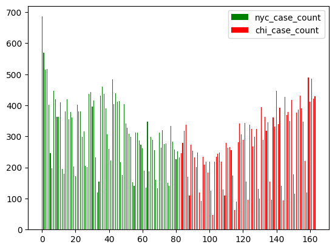

```python
#Visual 1 - FILL IN
import matplotlib.pyplot as plt
ax = plt.axes()
ax.bar(df_merged.index, df_merged['nyc_case_count'], width=0.4, color='g', label='nyc_case_count')
ax.bar(df_merged.index, df_merged['chi_case_count'], width=0.4, color='r', label='chi_case_count')
plt.legend()
plt.show()
```

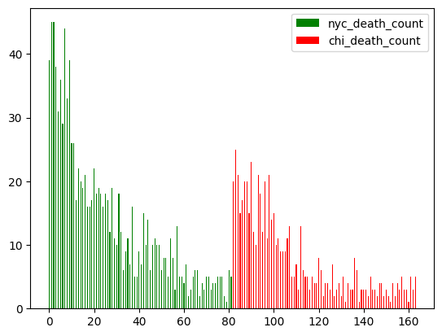

```python
#Visual 2 - FILL IN
import matplotlib.pyplot as plt
ax = plt.axes()
ax.bar(df_merged.index, df_merged['nyc_death_count'], width=0.4, color='g', label='nyc_death_count')
ax.bar(df_merged.index, df_merged['chi_death_count'], width=0.4, color='r', label='chi_death_count')
plt.legend()
plt.show()
```

### **5.2:** Reflection

In 2-4 sentences, if you had more time to complete the project, what actions would you take? For example, which data quality and structural issues would you look into further, and what research questions would you further explore?

*Answer:* If I had more time to complete the project, I would look more into how I could incorporate some of the other columns that I felt like were not relevant to the reserach question. Some further research questions I would explore would be the about factors behind the findings in my datasets.